# Assignment 3 Econ320

D.Z.

05 January, 2020

# Multicolinearity detection and output presentation

Using the data gpa1 from the wooldridge package create two new variables in the gpa1 data set

$$x = 3+ ACT*2$$

```r
data(gpa1, package = "wooldridge")
x <- 3 + gpa1$ACT*2
```

$$z=ACT+2*hsGPA$$

```r
z <- gpa1$ACT + 2*(gpa1$hsGPA)
```

Create a correlation matrix of colGPA, hsGPA, ACT, x, z, and a correlation matrix graph

This graph is not my favorite graph, it is too busy, but it will do the trick for now. What can you say about the correlation matrix and the graphs? Note: Extra points if you do another cooler graph!!!Like corrplot or chart.Correlation.

```r
dta1 <- gpa1 %>% select(colGPA, hsGPA, ACT)
dta1$x <- (dta1$ACT)*2 + 3
dta1$z <- (dta1$ACT) + 2*(dta1$hsGPA)
cor1 <- cor(dta1)
round(cor1, 3)
```

```
##        colGPA hsGPA   ACT     x     z
## colGPA  1.000 0.415 0.207 0.207 0.273
## hsGPA   0.415 1.000 0.346 0.346 0.520
## ACT     0.207 0.346 1.000 1.000 0.981
## x       0.207 0.346 1.000 1.000 0.981
## z       0.273 0.520 0.981 0.981 1.000
```

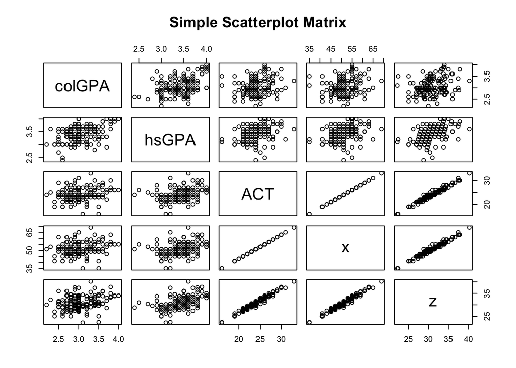

```r
cor1mtx <- pairs(~ colGPA + hsGPA + ACT + x + z, data = dta1,
   main="Simple Scatterplot Matrix")
```

Run the following six regressions, and show them al, toguether in a nice looking table

$$colGPA=\beta_0 + \beta_1hsGPA + \beta_2ACT + u$$
$$colGPA=\beta_0 + \beta_1hsGPA + \beta_2ACT + + \beta_3x + + \beta_4z + u$$

Make a summary of the second regression, look at it. Then make sure that the output of the code for it doesn’t show, this is just for you to see how R reacts to the multicolinearity problem. EXPLAIN what happened in the output and why.

```r
lm1 <- lm(formula = colGPA ~ hsGPA + ACT, data = dta1)
lm2 <- lm(formula = colGPA ~ hsGPA + ACT + x + z, data = dta1)
# In the summary of the second regression, the coefficients of x and z are not available in the summary. This is due to the fact that x and z can be derived from other variables in the regression function. R omits the coefficients of these variables, and regard them as "excessive information".
```

```r
stargazer(lm1, lm2, title = "Determinants of College GPA", dep.var.caption = "College GPA", dep.var.labels = "Previous Academics", column.labels = c("Basic Model", "Model with multicolinearity"), covariate.labels = c("High SchoolGPA", "ACT", "x", "z"), type = 'html')
```

**Determinants of College GPA**

|  | College GPA |  |
| --- | --- | --- |
|  | Previous Academics |  |
|  | Basic Model | Model with multicolinearity |
|  | (1) | (2) |
| High SchoolGPA | 0.453*** | 0.453*** |
|  | (0.096) | (0.096) |
| ACT | 0.009 | 0.009 |
|  | (0.011) | (0.011) |
| x |  |  |
| z |  |  |
| Constant | 1.286*** | 1.286*** |
|  | (0.341) | (0.341) |
| Observations | 141 | 141 |
| R<sup>2</sup> | 0.176 | 0.176 |
| Adjusted R<sup>2</sup> | 0.164 | 0.164 |
| Residual Std. Error (df = 138) | 0.340 | 0.340 |
| F Statistic (df = 2; 138) | 14.781*** | 14.781*** |
| *Note:* | p<0.1; p<0.05; p<0.01 |  |

Show the results for your regressions using the stargazaer package

# Prove some OLS properties

Use R to

- evaluate the vif of model1 and model2. See what happens to model2, comment, and fix the code to be able to knit

```r
vif(lm1)
```

```
##    hsGPA      ACT
## 1.135823 1.135823
```

```r
# The reason we can't do vif(lm2) is due to the fact that x and z in lm2 can be derived through hsGPA and ACT, thus we run into the error code of "... there are aliased coefficients in this model."
```

- demonstrate that the residuals of model1 add up to zero. What does that mean? EXPLAIN

```r
u=resid(lm1)
round(sum(u),2)
```

```
## [1] 0
```

```r
#This means that our model generates the "line of best fit".
```

- demonstrate the $R^2$ of a regression of the residuals of model1 on the original regressors must be zero. What does this mean? EXPLAIN

```r
round(cor(u, lm1$model$hsGPA), 3)
```

```
## [1] 0
```

```r
round(cor(u, lm1$model$ACT), 3)
```

```
## [1] 0
```

```r
# This imply that there is no component in residuals of model 1 that haven't been explained by our regressors.
```